```r
library(tidyverse)
```

```r
library(ggplot2)
# library(ggThemeAssist)
library(gridExtra)
library(gbm)
library(pROC)
heart.data <- read_csv("heart_attack_prediction_dataset.csv")
```

Before performing any analysis, I did a simple tidying on the data, including rename, factorizing indicator variables, and deal with special format variable(blood pressure). Luckily we do not get and missing data or undefined values in this dataset. Here a beirf summary table of the data is generated.

```r
# problems(heart.data) %>% print()
heart.data_tidied <- heart.data %>% mutate(diabetes = as.factor(Diabetes),
                      family_history = as.factor(`Family History`),
                      smoking = as.factor(Smoking),
                      obesity = as.factor(Obesity),
                      alcohol = as.factor(`Alcohol Consumption`),
                      previous_problems = as.factor(`Previous Heart Problems`),
                      medication = as.factor(`Medication Use`),
                      heart_attack = as.factor(`Heart Attack Risk`),
                      Sex = as.factor(Sex),
                      Diet = as.factor(Diet),
                      stress = as.factor(`Stress Level`),
                      Country = as.factor(Country),
                      Continent = as.factor(Continent),
                      Hemisphere = as.factor(Hemisphere)) %>%
                    select(-Diabetes, -`Family History`, -Smoking, -Obesity, -`Alcohol Consumption`, -`Previous Heart Problems`,-`Medication Use`, -`Heart Attack Risk`,-`Stress Level`)

heart.data_tidied <- heart.data_tidied %>%
  mutate(bld_pressure_split = strsplit(as.character(`Blood Pressure`), "/")) %>%
  mutate(bld_pressure_upper = as.numeric(sapply(bld_pressure_split, `[`, 1)),
         bld_pressure_lower = as.numeric(sapply(bld_pressure_split, `[`, 2))) %>%
  select(-bld_pressure_split, -`Blood Pressure`) %>%
  mutate(high_bld_pressure = as.factor(ifelse(bld_pressure_upper >=130 & bld_pressure_lower >=80,1,0)))

print(summary(heart.data_tidied))
```

```
##   Patient ID             Age            Sex        Cholesterol
##  Length:8763        Min.   :18.00   Female:2652   Min.   :120.0
##  Class :character   1st Qu.:35.00   Male  :6111   1st Qu.:192.0
##  Mode  :character   Median :54.00                 Median :259.0
##                     Mean   :53.71                 Mean   :259.9
##                     3rd Qu.:72.00                 3rd Qu.:330.0
##                     Max.   :90.00                 Max.   :400.0
##
##    Heart Rate     Exercise Hours Per Week        Diet
##  Min.   : 40.00   Min.   : 0.002442       Average  :2912
##  1st Qu.: 57.00   1st Qu.: 4.981579       Healthy  :2960
##  Median : 75.00   Median :10.069559       Unhealthy:2891
##  Mean   : 75.02   Mean   :10.014284
##  3rd Qu.: 93.00   3rd Qu.:15.050018
##  Max.   :110.00   Max.   :19.998709
##
##  Sedentary Hours Per Day     Income            BMI        Triglycerides
##  Min.   : 0.001263       Min.   : 20062   Min.   :18.00   Min.   : 30.0
##  1st Qu.: 2.998794       1st Qu.: 88310   1st Qu.:23.42   1st Qu.:225.5
##  Median : 5.933622       Median :157866   Median :28.77   Median :417.0
##  Mean   : 5.993690       Mean   :158263   Mean   :28.89   Mean   :417.7
##  3rd Qu.: 9.019124       3rd Qu.:227749   3rd Qu.:34.32   3rd Qu.:612.0
##  Max.   :11.999313       Max.   :299954   Max.   :40.00   Max.   :800.0
##
##  Physical Activity Days Per Week Sleep Hours Per Day           Country
##  Min.   :0.00                    Min.   : 4.000      Germany       : 477
##  1st Qu.:2.00                    1st Qu.: 5.000      Argentina     : 471
##  Median :3.00                    Median : 7.000      Brazil        : 462
##  Mean   :3.49                    Mean   : 7.024      United Kingdom: 457
##  3rd Qu.:5.00                    3rd Qu.: 9.000      Australia     : 449
##  Max.   :7.00                    Max.   :10.000      Nigeria       : 448
##                                                      (Other)       :5999
##          Continent                  Hemisphere   diabetes family_history
##  Africa       : 873   Northern Hemisphere:5660   0:3047   0:4443
##  Asia         :2543   Southern Hemisphere:3103   1:5716   1:4320
##  Australia    : 884
##  Europe       :2241
##  North America: 860
##  South America:1362
##
##  smoking  obesity  alcohol  previous_problems medication heart_attack
##  0: 904   0:4369   0:3522   0:4418            0:4396     0:5624
##  1:7859   1:4394   1:5241   1:4345            1:4367     1:3139
##
##
##
##
##
##      stress     bld_pressure_upper bld_pressure_lower high_bld_pressure
##  2      : 913   Min.   : 90.0      Min.   : 60.00     0:5730
##  4      : 910   1st Qu.:112.0      1st Qu.: 72.00     1:3033
##  7      : 903   Median :135.0      Median : 85.00
##  9      : 887   Mean   :135.1      Mean   : 85.16
##  8      : 879   3rd Qu.:158.0      3rd Qu.: 98.00
##  3      : 868   Max.   :180.0      Max.   :110.00
##  (Other):3403
```

I am interested in the associations between covariates and heart attack risk, and after determining the covariates that contributes the most, I can fit a prediction model on heart attack risk.

First, let’s try to get a general sense on how these covariates associated with heart attack. For categorial variables, I used a histogram to show the heart attack frequencies in different groups. For continuous variables, I naively fitted a logistic regression without checking any assumptions.

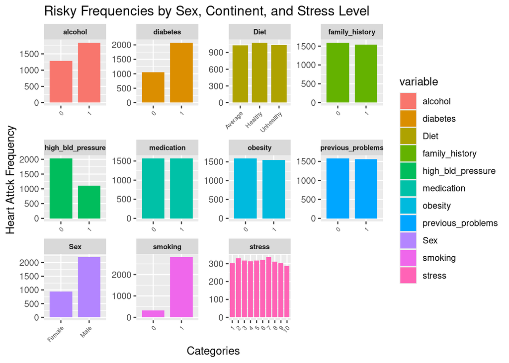

```r
risky_data <- heart.data_tidied %>% filter(heart_attack == 1)

# Reshape data for plotting
risky_data_long <- risky_data %>%
  pivot_longer(cols = c(Sex, Diet, diabetes, family_history, smoking, obesity, alcohol, previous_problems, medication, stress, high_bld_pressure), names_to = "variable", values_to = "value")

# Plot a single histogram
histogram.acoss_variable <- ggplot(risky_data_long, aes(x = value, fill = variable)) +
  geom_bar(position = position_dodge(width = 0.9),width = 0.8) +
  facet_wrap(~variable, scales = "free")+
  labs(title = "Risky Frequencies by Sex, Continent, and Stress Level", x = "Categories", y = "Heart Attck Frequency") +
  theme(
    strip.text = element_text(size = 7, face = "bold"),
    axis.text.x = element_text(angle = 45, hjust = 1,size=6),  # Rotate x-axis labels
    legend.position = "right"
  )
histogram.acoss_variable
```

```r
model <- glm(heart_attack ~ Age + Cholesterol + `Heart Rate` + `Exercise Hours Per Week` +
            `Sedentary Hours Per Day` + Income + BMI +
              Triglycerides + `Sleep Hours Per Day`,
              data = heart.data_tidied, family = binomial)

print(summary(model))
```

```
##
## Call:
## glm(formula = heart_attack ~ Age + Cholesterol + `Heart Rate` +
##     `Exercise Hours Per Week` + `Sedentary Hours Per Day` + Income +
##     BMI + Triglycerides + `Sleep Hours Per Day`, family = binomial,
##     data = heart.data_tidied)
##
## Coefficients:
##                             Estimate Std. Error z value Pr(>|z|)
## (Intercept)               -6.715e-01  1.959e-01  -3.427  0.00061 ***
## Age                        6.488e-04  1.049e-03   0.618  0.53640
## Cholesterol                5.017e-04  2.760e-04   1.818  0.06903 .
## `Heart Rate`              -4.597e-04  1.085e-03  -0.424  0.67176
## `Exercise Hours Per Week`  3.969e-03  3.857e-03   1.029  0.30348
## `Sedentary Hours Per Day` -3.694e-03  6.434e-03  -0.574  0.56583
## Income                     2.518e-07  2.768e-07   0.910  0.36286
## BMI                       -1.718e-04  3.529e-03  -0.049  0.96117
## Triglycerides              9.257e-05  9.971e-05   0.928  0.35322
## `Sleep Hours Per Day`     -1.911e-02  1.122e-02  -1.704  0.08841 .
## ---
## Signif. codes:  0 '***' 0.001 '**' 0.01 '*' 0.05 '.' 0.1 ' ' 1
##
## (Dispersion parameter for binomial family taken to be 1)
##
##     Null deviance: 11434  on 8762  degrees of freedom
## Residual deviance: 11424  on 8753  degrees of freedom
## AIC: 11444
##
## Number of Fisher Scoring iterations: 4
```

From the histogram and logistic model above, we can see that, not all variables are highly related to heart attack. To select the most relevant variables and prevent overfit of the final prediction model, here perform a PCA.

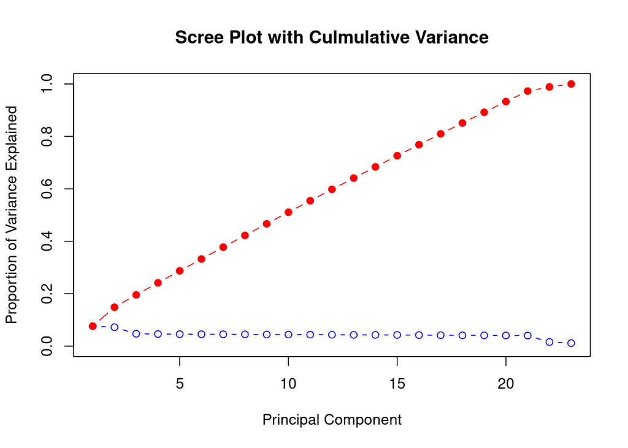

```r
heart.data_pca <- heart.data_tidied %>%
                  mutate(sex = ifelse(Sex == "Male",1,0),
                         diet = ifelse(Diet == "Unhealthy",1,0))
pca.result <- prcomp(heart.data_pca %>%
                     select(-`Patient ID`, -heart_attack,-Continent,-Country,-Hemisphere, -Sex, -Diet) %>%
                    mutate(across(everything(), as.numeric))%>%
                    as.matrix(),
                    scale. = T, center = T)

pca.score <- as.data.frame(pca.result$x)

explained_variance <- pca.result$sdev^2 / sum(pca.result$sdev^2)
cumulative_variance <- cumsum(explained_variance)

# Plot the scree plot

plot(explained_variance, type = "b", col="blue",
     xlab = "Principal Component",
     ylab = "Proportion of Variance Explained",
     ylim = c(0:1),
     main = "Scree Plot with Culmulative Variance")
lines(cumulative_variance, type = "b", pch = 19, col = "red")
```

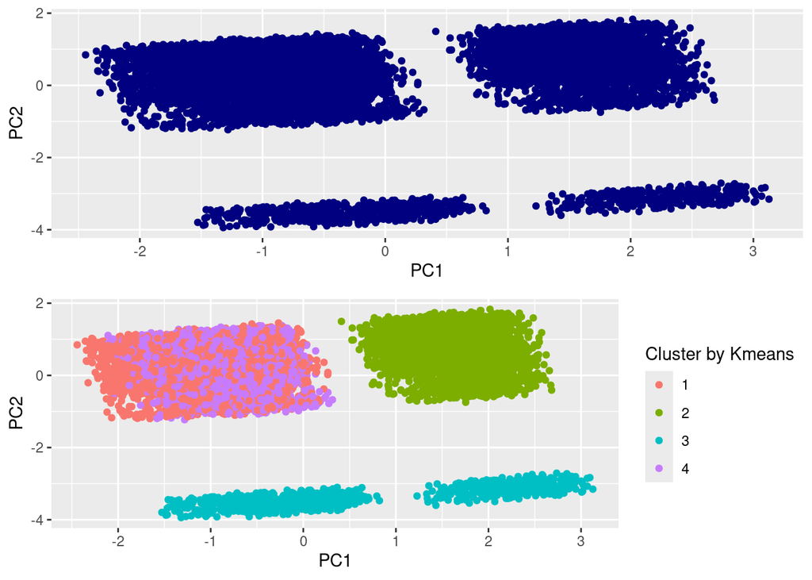

```r
plot1<-ggplot(data=pca.score %>%as.tibble() %>% select(PC1, PC2), aes(PC1,PC2)) +
  geom_point(color = "navy")
heart.data_kmeans <- heart.data_pca %>%
                     select(-`Patient ID`, -heart_attack,-Continent,-Country,-Hemisphere, -Sex, -Diet)%>%
                      mutate(across(everything(), as.numeric))%>%
                     scale(center = TRUE, scale = TRUE)
pcd_kmeans<- pca.score %>% as.tibble() %>% mutate(lables=kmeans(heart.data_kmeans,centers=4)$cluster)%>%
      select(PC1,PC2,lables)
plot3<-ggplot(data=pcd_kmeans, aes(PC1,PC2)) +
  geom_point(aes(colour = factor(lables)))+
  labs(color = "Cluster by Kmeans")


pcd_continent <- pca.score %>% as.tibble() %>% mutate(continent=heart.data_pca$Continent)%>%
      select(PC1,PC2,continent)


plot2<-ggplot(data=pcd_continent, aes(PC1,PC2)) +
  geom_point(aes(colour = factor(continent)))+
  labs(color = "Continent")+
  theme(legend.position = "right", legend.box = "vertical",
        axis.title = element_text(size = 9,vjust = 0),
        legend.text = element_text(size = 7),
    legend.title = element_text(size = 9),
    legend.key = element_rect(fill = NA))

pcd_country <- pca.score %>% as.tibble() %>% mutate(country=heart.data_pca$Country)%>%
      select(PC1,PC2,country)
plot4<-ggplot(data=pcd_country, aes(PC1,PC2)) +
  geom_point(aes(colour = factor(country)))+
  labs(color = "Country")+
  guides(colour = guide_legend(ncol  = 2))+
  theme(legend.position = "right", legend.box = "vertical",
        axis.title = element_text(size = 9,vjust = 0),
        legend.text = element_text(size = 7),
    legend.title = element_text(size = 9),
    legend.key = element_rect(fill = NA))
# ggThemeAssistGadget(p)

grid.arrange(plot1,plot3)
```

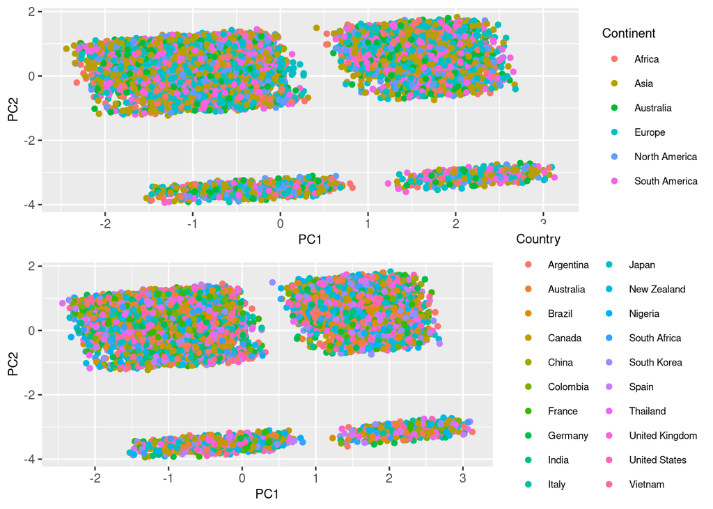

```r
grid.arrange(plot2, plot4)
```

The four figures are all scatter plots of observation after projecting onto PC1 and PC2.

The third one and fourth one are colored by continent and country. I just think it would be interesting to see if people live in same area will share some certain life habit or characteristics that would increase/reduce heart attack risk, but as we seen, individuals from different places are evenly distributed in the 4 clusters.

```r
pcd1 <- pca.score %>% as.tibble() %>% mutate(continent=heart.data_pca$Continent)%>%
      select(PC1,PC2,PC3,continent)
# Create a color palette
colors <- rainbow(length(unique(pcd1$continent)))
names(colors) <- unique(pcd1$continent)

# Plot the 3D PCA
library(plotly)
plot_ly(pcd1, x = ~PC1, y = ~PC2, z = ~PC3, color = ~continent, colors = "Set1",
        type = "scatter3d", mode = "markers") %>%
  layout(scene = list(xaxis = list(title = 'Principal Component 1'),
                      yaxis = list(title = 'Principal Component 2'),
                      zaxis = list(title = 'Principal Component 3')))
```

[interactive chart not shown]

```r
plot_ly
```

[output not shown]

[output cut: 8 more lines]

[output not shown]

It is a 3-dimention PCA score plot colored by continent. I thought maybe one more component would make some difference, but sadly not. I kept it anyway, at lease it looks cool.

Next, I want to fit a predication model. From what we got above, not all covariates need to be go into the model. So I select the variables by the absolute value of rotation coefficient.

```r
pca.rotation <- pca.result$rotation %>% as.data.frame() %>% mutate(covariates = rownames(.))

rotation.pc1 <- pca.rotation[,1] %>% abs() %>% as.data.frame()%>%
                mutate(covariates = rownames(pca.rotation))%>%
                arrange(desc(.))

rotation.pc2 <- pca.rotation[,2] %>% abs() %>% as.data.frame()%>%
                mutate(covariates = rownames(pca.rotation))%>%
                arrange(desc(.))
head(rotation.pc1$covariates,10) %>% print
```

```
##  [1] "high_bld_pressure"               "bld_pressure_upper"
##  [3] "bld_pressure_lower"              "smoking"
##  [5] "sex"                             "Age"
##  [7] "stress"                          "obesity"
##  [9] "Physical Activity Days Per Week" "Exercise Hours Per Week"
```

```r
head(rotation.pc2$covariates,10) %>% print
```

```
##  [1] "smoking"                 "sex"
##  [3] "Age"                     "high_bld_pressure"
##  [5] "bld_pressure_upper"      "bld_pressure_lower"
##  [7] "Sedentary Hours Per Day" "Heart Rate"
##  [9] "family_history"          "Cholesterol"
```

```r
heart.data_model <- heart.data_pca %>% select("high_bld_pressure","smoking","Age","stress","obesity",
                                            `Physical Activity Days Per Week`,`Sedentary Hours Per Day`,
                                            "family_history","Cholesterol",Income)%>%
                                        mutate(heart_attack = as.numeric(heart.data_pca$heart_attack)-1)%>%mutate(stress = as.numeric(heart.data_pca$stress))


set.seed(611)
train_ii <- runif(nrow(heart.data_model)) < 0.85
train <- heart.data_model %>% filter(train_ii)
test <- heart.data_model %>% filter(!train_ii)

model <- glm(heart_attack ~ ., data = train,family = binomial)
summary(model)
```

```
##
## Call:
## glm(formula = heart_attack ~ ., family = binomial, data = train)
##
## Coefficients:
##                                     Estimate Std. Error z value Pr(>|z|)
## (Intercept)                       -7.000e-01  1.470e-01  -4.763 1.91e-06 ***
## high_bld_pressure1                 4.293e-02  5.061e-02   0.848   0.3963
## smoking1                          -9.703e-02  8.545e-02  -1.135   0.2562
## Age                                1.262e-03  1.239e-03   1.019   0.3082
## stress                            -7.337e-03  8.404e-03  -0.873   0.3827
## obesity1                          -4.945e-02  4.820e-02  -1.026   0.3049
## `Physical Activity Days Per Week` -2.703e-03  1.054e-02  -0.256   0.7976
## `Sedentary Hours Per Day`         -1.836e-03  6.967e-03  -0.263   0.7922
## family_history1                    1.927e-02  4.819e-02   0.400   0.6893
## Cholesterol                        5.676e-04  2.987e-04   1.900   0.0574 .
## Income                             3.509e-07  2.990e-07   1.174   0.2406
## ---
## Signif. codes:  0 '***' 0.001 '**' 0.01 '*' 0.05 '.' 0.1 ' ' 1
##
## (Dispersion parameter for binomial family taken to be 1)
##
##     Null deviance: 9792.2  on 7494  degrees of freedom
## Residual deviance: 9782.7  on 7484  degrees of freedom
## AIC: 9804.7
##
## Number of Fisher Scoring iterations: 4
```

```r
prediction <- predict(model, newdata = test, type = "response")
roc.result<-roc(test$heart_attack,prediction)
```

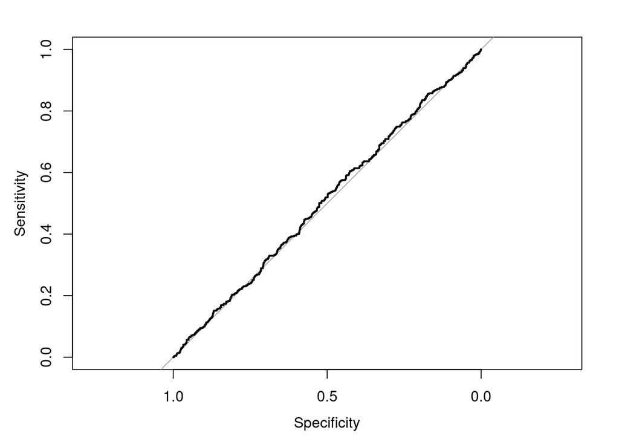

```r
plot(roc.result)
```

Randomly choose 85% observation as training set, the rest as testing set. Put the variables selected above into a logistic model. Perform prediction on test data and draw ROC plot. But sadly the model performs not good(ROC =0.5), basically equivalent to random guess. Even adding all available covariates into the model did not improve the performance. Maybe because it is artificial dataset?

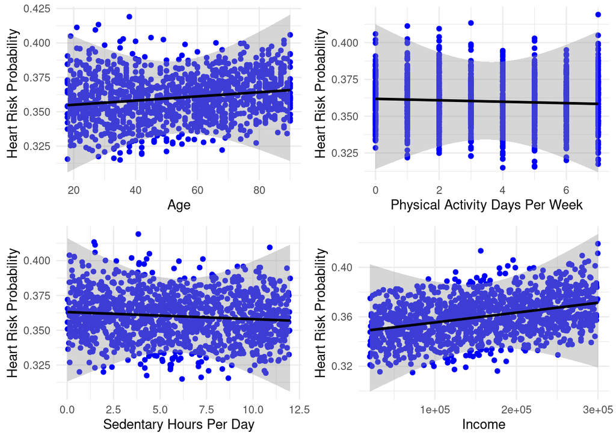

```r
# Create a data frame for plotting
plot_data <- test %>% mutate(predicted_risk = prediction)

# Plot the logistic regression curve along with the observed data points
p1 <- ggplot(plot_data, aes(x =Age, y = predicted_risk)) +
  geom_point(color = "blue") +
  geom_smooth(method = "glm", method.args = list(family = "binomial"), color = "black") +
  labs(x = "Age",
       y = "Heart Risk Probability") +
  theme_minimal()

p2<-ggplot(plot_data, aes(x =`Physical Activity Days Per Week`, y = predicted_risk)) +
  geom_point(color = "blue") +
  geom_smooth(method = "glm", method.args = list(family = "binomial"), color = "black") +
  labs(x = "Physical Activity Days Per Week",
       y = "Heart Risk Probability") +
  theme_minimal()

p3<- ggplot(plot_data, aes(x =`Sedentary Hours Per Day`, y = predicted_risk)) +
  geom_point(color = "blue") +
  geom_smooth(method = "glm", method.args = list(family = "binomial"), color = "black") +
  labs(x = "Sedentary Hours Per Day",
       y = "Heart Risk Probability") +
  theme_minimal()

p4<- ggplot(plot_data, aes(x = Income, y = predicted_risk)) +
  geom_point(color = "blue") +
  geom_smooth(method = "glm", method.args = list(family = "binomial"), color = "black") +
  labs(x = "Income",
       y = "Heart Risk Probability") +
  theme_minimal()

grid.arrange(p1,p2,p3,p4,ncol=2)
```